# A Dark Figure Crime: Analyzing the Socioeconomic and Geographic Factors of Human Trafficking and Its Statistics

Author

Madison Mychayliw

Published

May 3, 2024

## Aim

Human trafficking has become an increasingly concerning public health issue, connecting factors at both the indivdual and societal levels (Sprang et al., 2022). From forced labor to sexual exploitation and child sex trafficking, hundreds of thousands of people become victims of human trafficking every year. Human trafficking involves the use of fraud, force, or coercion accompanied further by deception, abduction, or the abuse of power (Schroeder et al., 2022). While the act of trafficking can often go unnoticed by the general public, the statistics regarding it do not lie. Victims of trafficking include individuals from US citizens to undocumented immigrants and are of a variety of age demographics (Rothman et al., 2017). Other factors that influence victimization include geographical location, gender, and personal life experience. The socioeconomic and locational factors that lead to the victimization, as well as the demographics and venue locations where trafficking occurs, will be explored here.

## Question and Problem

Through this analysis, I will be addressing the question of what socioeconomic, geographical, and demographic factors make individuals vulnerable to trafficking and how do human trafficking offense statistics compare to other crimes?

## Scope

This will be studied through the trafficking statistics and data for the United States as a whole as well as the state of Pennsylvania

## Methods

The data used here comes from a variety of sources. One source includes data from the Polaris Project, which is NGO that works to educate and prevent trafficking in America. Additional data sources used here were from The Counter Trafficking Data Collaborative (CTDC), The National Human Trafficking Hotline, the United Judicial System of Pennsylvania, FBI Crime Data Explorer, and the United Nations Office on Drugs and Crime (UNODC).

## Results

**In the United States:**

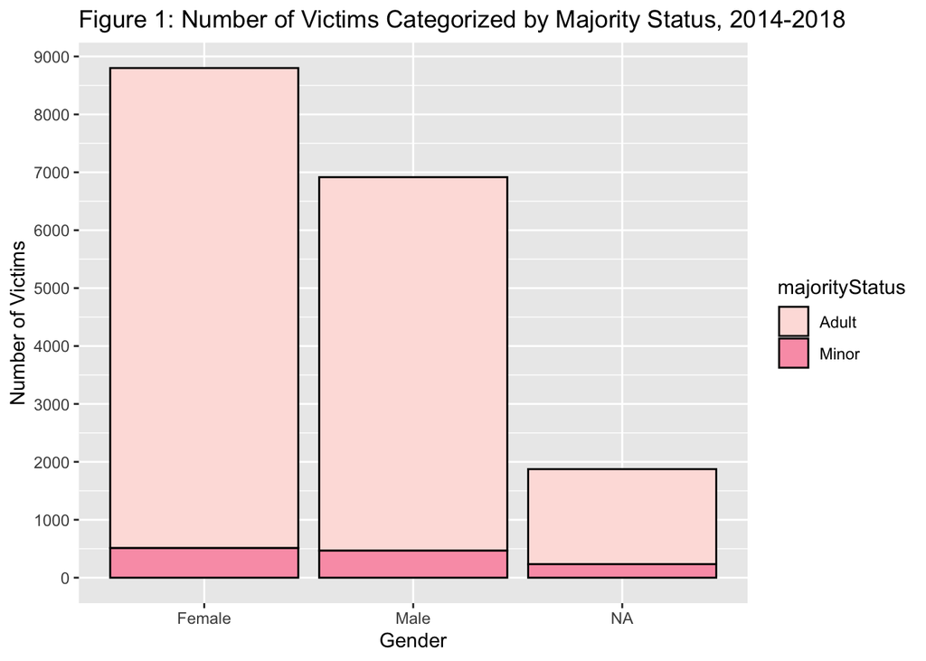

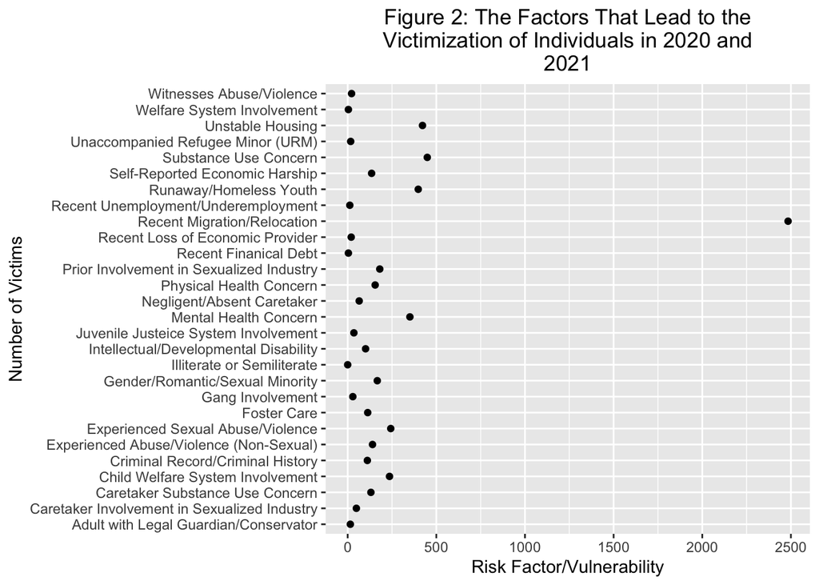

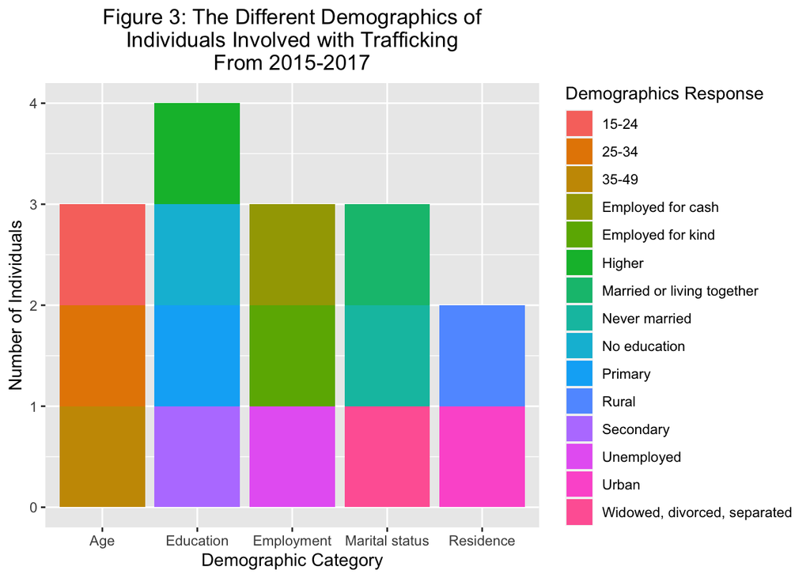

**In Pennsylvania:**

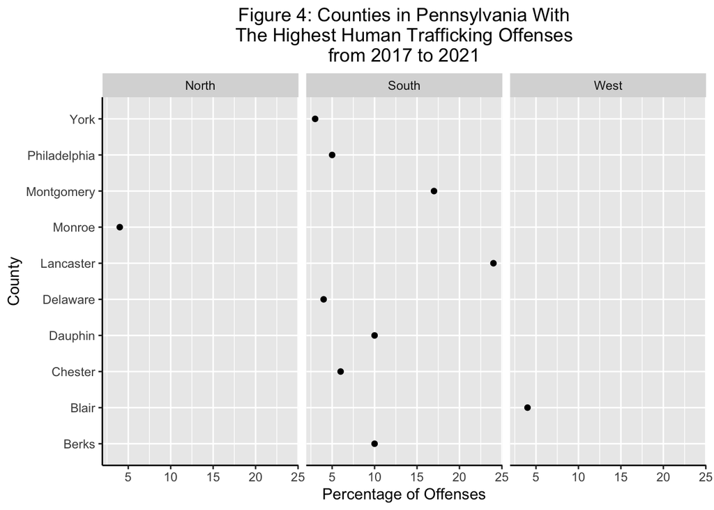

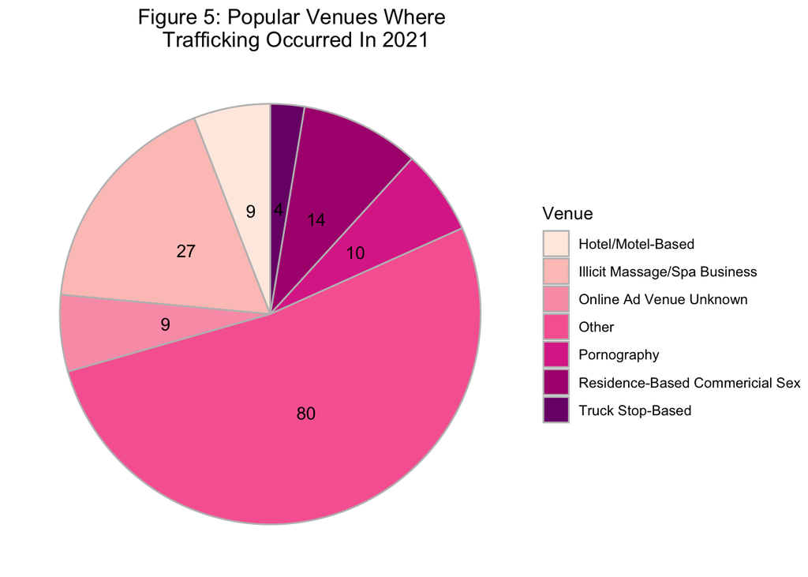

Figure 6: Human Trafficking Offenses As Compared to Total Crimes In 2022

| State Police | Total Offenses | Crimes Against Persons | Human Trafficking Offenses | Non Human Trafficking Offenses |
| --- | --- | --- | --- | --- |
| Lebanon County | 978 | 281 | 4 | 974 |
| Adams County | 1402 | 498 | 1 | 1401 |
| Berks County | 1630 | 523 | 1 | 1629 |
| Fayette County | 3831 | 1212 | 1 | 3830 |
| Huntingdon County | 1068 | 425 | 1 | 1067 |
| Lackawanna County | 593 | 202 | 1 | 592 |
| Philadelphia County | 1043 | 342 | 1 | 1042 |
| Washington County | 858 | 279 | 1 | 857 |
| Wyoming County | 2033 | 508 | 1 | 2032 |
| Allegheny County | 1010 | 202 | 0 | 1010 |

## Main Conclusions

In Pennsylvania, the county with the highest percentage of human trafficking offenses was Lancaster, which is located in the Southern part of Pennsylvania. The most popular venue where trafficking took place in Pennsylvania in 2021 was Illicit Massage/Spa Business, with Other venues making up a majority of the popular venues. Human Trafficking offenses were also seen to make up a very small portion of the total offenses attended to by state police in Pennsylvania. These results portray that human trafficking in Pennsylvania is most popular in the southern most part of the state, with state borders potentially playing a part in this.

Trafficking is known to be a “dark figure” crime, with there being hundreds and thousands of victims that are just not known about. As much as we would want their to be more research done, the most accurate data is just not out there simply because not every victim of trafficking can be accounted for. From these figures, it can be seen that adult females are one of the largest groups of people that are victims of trafficking, so providing more support to them and doing more research about women would be beneficial as women are often not studied in any area of research, but specifically here as it relates to trafficking. Backing off of this research, the more that victims and their experiences are taken seriously, the more research that can be done regarding them. From a law point of view, victims and their stories tend to be put on the ‘back-burner’ due to the prevalence of so many other crimes, so if these cases were looked into more, there would be more research and data regarding trafficking.

## References

*Peer-Reviewed Sources*

Rothman, E., Stoklosa, H., Baldwin, S., Chisolm-Straker, M., Price, R., Atkinson, H. (2017). Public Health Research Priorities to Address US Human Trafficking. American Public Health Association, 107 (7), 1045-1047.

Schroeder, E., Edgemon, G., Aletraris, L., Kagotho, N., Clay-Warner, J., Okech, D. (2022). A Review of Prevalence Estimation Methods for Human Trafficking Populations. Sage Journal, 137 (1), 46-52.

Sprang, G., Stoklosa, H., Greenbaum, J. (2022). The Public Health Response to Human Trafficking: A Look Back and a Step Foward. Sage Journals, 137 (1), 5S-9S.

*Data Sources*

CTDC. (2022). The Global Victim-Perpetrator Synthetic Data Set [Data set]. Retrieved from: https://www.ctdatacollaborative.org/page/global-synthetic-dataset

Federal Bureau of Investigation Crime Data Explorer. (2022). National Incident-Based Reporting System (NIBRS) Tables [Data file]. Retrieved from: https://cde.ucr.cjis.gov/LATEST/webapp/#

National Human Trafficking Hotline. (2021). Pennsylvania Statistics by Year [PDF and data file]. Retrieved from: https://humantraffickinghotline.org/en/statistics/pennsylvania

Polaris Project. (2021). Polaris Analysis of 2021 Data from the National Human Trafficking Hotline [PDF and data file]. Retrieved from: https://polarisproject.org/wp-content/uploads/2020/07/Polaris-Analysis-of-2021-Data-from-the-National-Human-Trafficking-Hotline.pdf

The United Judicial System of Pennsylvania. (2023). Cracking Down on Human Trafficking in Pennsylvania [PDF and data file]. Retrieved from: https://www.pacourts.us/news-and-statistics/news/news-detail/1124/cracking-down-on-human-trafficking-in-pennsylvania

UNODC. (2021). Trafficking in Persons-Detected Trafficking Victims [Data set]. Retrieved from: https://dataunodc.un.org/dp-trafficking-persons